# Factors Effecting Interest Rate for Borrowers

## Investigation Overview

In this investigation, it explores what factors were involved in assigning a borrower a certain interest rate when getting a loan.

## Dataset Overview

The dataset that was used contained over 110,000 different entries that had around 80 different columns. The dataset used for the following analysis was filtered down to four different columns that includes borrower interest rate, if the borrower is a homeowner, credit score range, and income range. Duplicate entries were removed, and the credit score columns were combined to show a range from 350-900 in intervals of 40.

## Distribution of Interest Rate

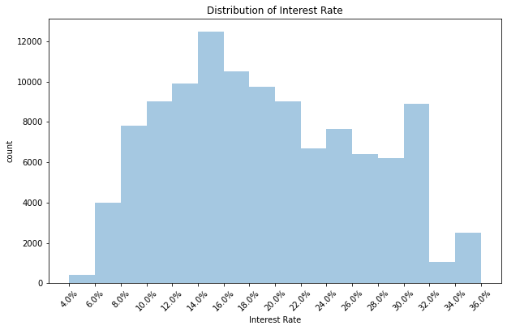

The distribution of interest rate falls between 4% and 36% for the borrowers in the dataset. It shows a bell curve distribution with a couple of spikes at 15% and 30%.

## Distribution of Credit Scores

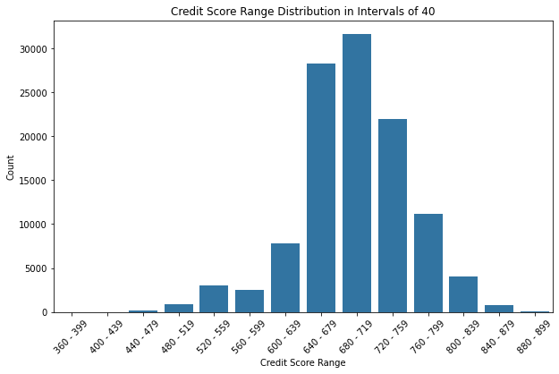

This shows the range of the borrowers having a credit score of 360 to 900. It shows most of the borrowers having a credit score between 600 and 800.

## Credit Scores vs Interest Rate

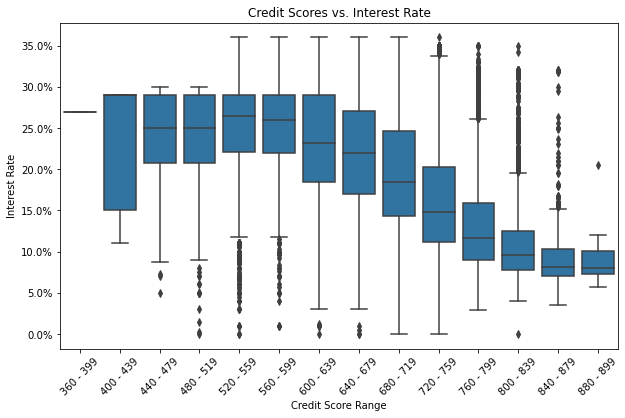

While the graph looks a little messy showing the dots, which are outliers for some borrowers in the dataset, most borrowers are getting assigned a lower interest rate if they have a higher credit score.

## Interest Rate vs Homeowner Status

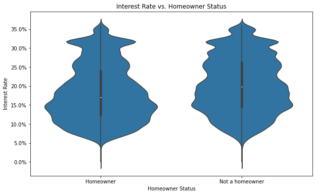

These two violin plots illustrate the relationship if a borrower is a homeowner. IF the borrower is a homeowner, it shows the shape of the violin is wider at the bottom and narrower on top while the reverse is true if the borrower is not a homeowner.

## Interest Rate vs Credit Scores Comparing Homeownership

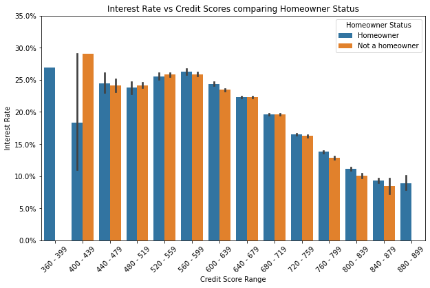

This shows Interest rate vs Credit Score Range comparing whether a borrower owns a home or not. Unlike the violin plots, this shows that non-homeowners that have the same credit rating as a homeowner generally have a slightly lower interest rate than a homeowner, which is surprising.

## Interest Rate vs Credit Scores Comparing Income Range

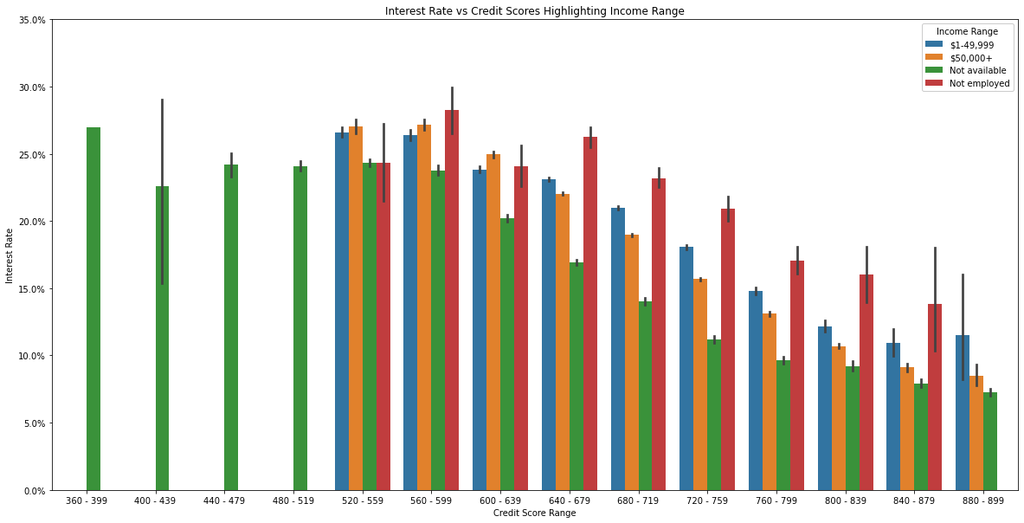

With credit scores below 520, there is no data that reflects the income of those borrowers. One thing that is obvious is that if borrowers are unemployed, they have a higher interest rate compared to other borrowers that have income. Also, borrowers that are below 50k income have a slighly higher interest rate than those borrowers that make more than 50k per year.